# Weight loss analysis for *The web architecture, dynamics, and silk investment in the social spider, Stegodyphus sarasinorum*

Thejasvi Beleyur

*This is one of three Rmd files accompanying the manuscript. The other files are called ‘beleyur_et_al_silk_analyses.Rmd’ (analyses the silk length on the web and the per-capita silk investment.’) and ‘beleyur_et_al_topology_analyses.Rmd’ (analyses the coordination number and pore size data)*

This notebook analyses the weight loss of individuals across the experiment to explore how individuals lost weight as a result of dessication + silk investment with group size. Here, the outcome variable is the weight loss and the predictor variables used will be: 1. weighing day (#days after experiment start) 1. body condition ($\frac{starting\:body\:weight}{cephalothorax\:width}$) 1. group-size

Colony name will also be used as a random effect, to account for colony-specific differences in silk-investment and dessication of spiders.

In general, the approach used here is to inspect model outputs from the default frequentist output using the `lmer` function, followed by Bayesian parameter estimation using non-informative priors with the `sim` function.

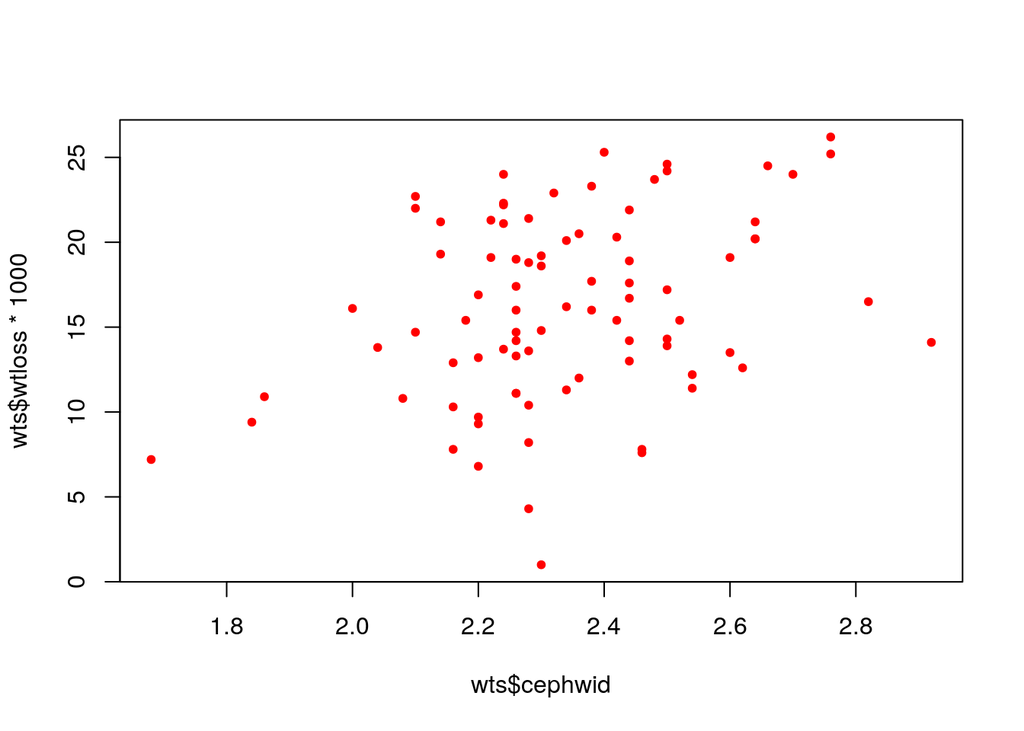

```r
library(arm)
library(coda)
library(dplyr)
library(gplots)
library(lme4)
set.seed(82319)
wtadrs<-'../../analysis input-data/finalwtsnsizes.csv' # address of the weights and sizes csvfile
wts_raw<-read.csv(wtadrs)

# 2020-09-02 : realised I had left some of the colonies in the dataset with excess spiders (caused by
# spiders ballooning their way from one web to the other) - and these need to be removed.

excess_spiders <- read.csv('excess_spiders.csv')
colonies_to_remove <- subset(excess_spiders, excess_spiders_observed==TRUE)$colonyname

#load function which removes all rows in the colonynames list/vector
source('remove_colonies.R')

wts <- remove_colonies(wts_raw, as.vector(colonies_to_remove),'colonyname')

wts<-subset(wts,wts$groupsize!='NA') # cleaning up the data frame once more to avoid an extra 'NA' group !
wts$wtloss<-wts$b4wt-wts$aftrwt


hqt<-round(quantile(wts$wtloss,0.975,na.rm=T),4)
lqt<-round(quantile(wts$wtloss,0.025,na.rm=T),4)
medn<-round(quantile(wts$wtloss,0.5,na.rm=T),4)


# now converting all the wts into milligrams with 1 decimal point accuracy - this is just to ease interpretation

wts$wtlossmg<-round(wts$wtloss*1000,1)
wts$b4wtmg<-round(wts$b4wt*1000,1)
wts$aftrwtmg<-round(wts$aftrwt*1000,1)
wts$wtlossmg<-round(wts$wtloss*1000,1)


# how much of missing data -(for Weightloss)  is there in this dataset ?
rws<-dim(wts)[1]
mssng<-sum(is.na(wts$wtloss))
pstagemiss<-mssng/rws

#are weight loss and spider size connected ? - let's check this out !
plot(wts$cephwid,wts$wtloss*1000,pch=20,col='red')
```

```r
cor.test(wts$cephwid,wts$wtloss,method='spearman')

# generate body condition
wts$body.cond <- wts$b4wtmg/wts$cephwid

wts$fact.gsize <- as.factor(wts$groupsize)
# standardise cephalothorax width
wts$std.cephwid <- (mean(wts$cephwid,na.rm=T)-wts$cephwid)/sd(wts$cephwid, na.rm=T)
wts$std.b4wtmg <- (mean(wts$b4wtmg,na.rm=T)-wts$b4wtmg)/sd(wts$b4wtmg, na.rm=T)
wts$std.wtlossmg <- (mean(wts$wtlossmg,na.rm=T)-wts$wtlossmg)/sd(wts$wtlossmg, na.rm=T)
wts$std.body.cond <- (mean(wts$body.cond,na.rm=T)-wts$body.cond)/sd(wts$body.cond, na.rm=T)



#dlenth <- subset(dlenth)
get.hpdintervals <- function(x,probrange=0.93)
{HPDinterval(as.mcmc(x),prob=probrange)}
get.med.hpdintervals <- function(x,probrange=0.93)
          {
          hpd.interval<-get.hpdintervals(x,probrange)
          med <- median(x)
          output <- c(hpd.interval[1],med,hpd.interval[2])
}
get.prob.lesser.value <- function(x,value){mean(x<value)}

wts.nona <- wts[complete.cases(select(wts,b4wtmg,wtday,fact.gsize,cephwid,std.cephwid)),]
```

[output not shown]

Now, let’s build the models.

```r
# both of these results suggest that there's an influence of previous weight, and size on silk investment
# maybe it's best to do some kind of linear model first to figure this out :

M0<-lm(wtlossmg~b4wtmg+wtday+fact.gsize+std.cephwid,data=wts.nona,
                  na.action="na.exclude")
res.M0 <- residuals(M0)
summary(M0)
```

```
##
## Call:
## lm(formula = wtlossmg ~ b4wtmg + wtday + fact.gsize + std.cephwid,
##     data = wts.nona, na.action = "na.exclude")
##
## Residuals:
##      Min       1Q   Median       3Q      Max
## -14.2728  -2.4296   0.2871   2.5929   7.0441
##
## Coefficients:
##              Estimate Std. Error t value Pr(>|t|)
## (Intercept)  -1.94615    6.36955  -0.306   0.7608
## b4wtmg        0.28034    0.04391   6.384  1.1e-08 ***
## wtday        -0.18321    0.46932  -0.390   0.6973
## fact.gsize5  -2.22216    2.71123  -0.820   0.4149
## fact.gsize10 -0.15484    2.33411  -0.066   0.9473
## fact.gsize25  1.99206    2.42334   0.822   0.4135
## std.cephwid   1.31611    0.76588   1.718   0.0896 .
## ---
## Signif. codes:  0 '***' 0.001 '**' 0.01 '*' 0.05 '.' 0.1 ' ' 1
##
## Residual standard error: 3.88 on 79 degrees of freedom
##   (25 observations deleted due to missingness)
## Multiple R-squared:  0.529,  Adjusted R-squared:  0.4933
## F-statistic: 14.79 on 6 and 79 DF,  p-value: 2.974e-11
```